# Programming III - Final Project

[figure not shown]

## Drew Carbone, Carter Che, Daria Lorenzo, Martin Ngoh, Peter Shoemaker, Martin Ngoh

## Big Data

- What is Big Data?
- Processing
  - Vertical Scaling "Scaling up"
  - Horizontal Scaling "Scaling Out"

## Tools for Big Data Processing

- Apache Spark
  - Clusters
  - Actions
- Spark APIs
  - PySpark (Python)
  - SparkR (R)
  - Sparklyr(R)
- Resilient Distributed Datasets (RDD)
  - Spark's core data structure
  - Nodes
  - Fault-tolerant
  - Dataframes
- Databricks
  - Notebook Format
  - Python, R, SQL
  - Spark native
  - Cloud-optimized platform

## PySpark vs Pandas

- PySpark (Spark API)
  - Two main libraries
    - Spark SQL (Big Data)
    - MLlib (Machine Learning)
  - Lazy Evaluation
    - Conserve and plan processing power
    - Optimized big data processing
    - Must call action
    - show() count()
- Pandas
  - No need for actions
- Pandas
  - df = pd.read_csv ("data.csv")
  - df
  - numpy
- Pyspark
  - df1 = spark.read.csv("data.csv", header = True, inferSchema = True)
  - df1.show()
  - pyspark.sql.functions

## Processing Big Data

- Cloud Computing
  - Virtual Machines (VMs)
  - Storage
  - Databases
- Cloud Providers
  - Computational power
  - AWS, Azure, Google Cloud

## Part 2 Analysis

### 1. Upload the dataset to your Databricks filestore

### 2. Read in the data and call it df

```python
%python
import pyspark.sql.functions as F
# File location and type
file_location = "/FileStore/tables/bank_transactions.csv"
file_type = "csv"

# CSV options
infer_schema = "True"
first_row_is_header = "True"
delimiter = ","

# The applied options are for CSV files. For other file types, these will be ignored.
df = spark.read.format(file_type) \
  .option("inferSchema", infer_schema) \
  .option("header", first_row_is_header) \
  .option("sep", delimiter) \
  .load(file_location)

display(df)
```

| step | type | amount | nameOrig | oldbalanceOrg | newbalanceOrig | nameDest | oldbalanceDest | newbalanceDest | isFraud | isFlaggedFraud |
| --- | --- | --- | --- | --- | --- | --- | --- | --- | --- | --- |
| 1 | PAYMENT | 9839.64 | C1231006815 | 170136.0 | 160296.36 | M1979787155 | 0.0 | 0.0 | 0 | 0 |
| 1 | PAYMENT | 1864.28 | C1666544295 | 21249.0 | 19384.72 | M2044282225 | 0.0 | 0.0 | 0 | 0 |
| 1 | TRANSFER | 181.0 | C1305486145 | 181.0 | 0.0 | C553264065 | 0.0 | 0.0 | 1 | 0 |
| 1 | CASH_OUT | 181.0 | C840083671 | 181.0 | 0.0 | C38997010 | 21182.0 | 0.0 | 1 | 0 |
| 1 | PAYMENT | 11668.14 | C2048537720 | 41554.0 | 29885.86 | M1230701703 | 0.0 | 0.0 | 0 | 0 |
| 1 | PAYMENT | 7817.71 | C90045638 | 53860.0 | 46042.29 | M573487274 | 0.0 | 0.0 | 0 | 0 |
| 1 | PAYMENT | 7107.77 | C154988899 | 183195.0 | 176087.23 | M408069119 | 0.0 | 0.0 | 0 | 0 |
| 1 | PAYMENT | 7861.64 | C1912850431 | 176087.23 | 168225.59 | M633326333 | 0.0 | 0.0 | 0 | 0 |
| 1 | PAYMENT | 4024.36 | C1265012928 | 2671.0 | 0.0 | M1176932104 | 0.0 | 0.0 | 0 | 0 |
| 1 | DEBIT | 5337.77 | C712410124 | 41720.0 | 36382.23 | C195600860 | 41898.0 | 40348.79 | 0 | 0 |
| 1 | DEBIT | 9644.94 | C1900366749 | 4465.0 | 0.0 | C997608398 | 10845.0 | 157982.12 | 0 | 0 |
| 1 | PAYMENT | 3099.97 | C249177573 | 20771.0 | 17671.03 | M2096539129 | 0.0 | 0.0 | 0 | 0 |
| 1 | PAYMENT | 2560.74 | C1648232591 | 5070.0 | 2509.26 | M972865270 | 0.0 | 0.0 | 0 | 0 |
| 1 | PAYMENT | 11633.76 | C1716932897 | 10127.0 | 0.0 | M801569151 | 0.0 | 0.0 | 0 | 0 |
| 1 | PAYMENT | 4098.78 | C1026483832 | 503264.0 | 499165.22 | M1635378213 | 0.0 | 0.0 | 0 | 0 |
| 1 | CASH_OUT | 229133.94 | C905080434 | 15325.0 | 0.0 | C476402209 | 5083.0 | 51513.44 | 0 | 0 |
| 1 | PAYMENT | 1563.82 | C761750706 | 450.0 | 0.0 | M1731217984 | 0.0 | 0.0 | 0 | 0 |
| 1 | PAYMENT | 1157.86 | C1237762639 | 21156.0 | 19998.14 | M1877062907 | 0.0 | 0.0 | 0 | 0 |
| 1 | PAYMENT | 671.64 | C2033524545 | 15123.0 | 14451.36 | M473053293 | 0.0 | 0.0 | 0 | 0 |
| 1 | TRANSFER | 215310.3 | C1670993182 | 705.0 | 0.0 | C1100439041 | 22425.0 | 0.0 | 0 | 0 |
| 1 | PAYMENT | 1373.43 | C20804602 | 13854.0 | 12480.57 | M1344519051 | 0.0 | 0.0 | 0 | 0 |
| 1 | DEBIT | 9302.79 | C1566511282 | 11299.0 | 1996.21 | C1973538135 | 29832.0 | 16896.7 | 0 | 0 |
| 1 | DEBIT | 1065.41 | C1959239586 | 1817.0 | 751.59 | C515132998 | 10330.0 | 0.0 | 0 | 0 |
| 1 | PAYMENT | 3876.41 | C504336483 | 67852.0 | 63975.59 | M1404932042 | 0.0 | 0.0 | 0 | 0 |
| 1 | TRANSFER | 311685.89 | C1984094095 | 10835.0 | 0.0 | C932583850 | 6267.0 | 2719172.89 | 0 | 0 |
| 1 | PAYMENT | 6061.13 | C1043358826 | 443.0 | 0.0 | M1558079303 | 0.0 | 0.0 | 0 | 0 |
| 1 | PAYMENT | 9478.39 | C1671590089 | 116494.0 | 107015.61 | M58488213 | 0.0 | 0.0 | 0 | 0 |
| 1 | PAYMENT | 8009.09 | C1053967012 | 10968.0 | 2958.91 | M295304806 | 0.0 | 0.0 | 0 | 0 |
| 1 | PAYMENT | 8901.99 | C1632497828 | 2958.91 | 0.0 | M33419717 | 0.0 | 0.0 | 0 | 0 |
| 1 | PAYMENT | 9920.52 | C764826684 | 0.0 | 0.0 | M1940055334 | 0.0 | 0.0 | 0 | 0 |

[output cut: 970 more lines]

Showing the first 1000 rows.

### 3. Check the schema of the dataset

```python
%python
# Print schema
df.printSchema()
```

root -- step: integer (nullable = true) -- type: string (nullable = true) -- amount: double (nullable = true) -- nameOrig: string (nullable = true) -- oldbalanceOrg: double (nullable = true) -- newbalanceOrig: double (nullable = true) -- nameDest: string (nullable = true) -- oldbalanceDest: double (nullable = true) -- newbalanceDest: double (nullable = true) -- isFraud: integer (nullable = true) -- isFlaggedFraud: integer (nullable = true)

### 4.Create a new column called destination_diff by subtracting oldbalanceDest from newbalanceDest

```python
%python
# Create new column AS 'destination_diff'
df1 = df.select('*', (df.newbalanceDest - df.oldbalanceDest).alias('destination_diff'))
# show the top rows
df1.show()
```

+----+--------+---------+-----------+-------------+--------------+-----------+--------------+--------------+-------+--------------+-------------------+ step| type| amount| nameOrig|oldbalanceOrg|newbalanceOrig| nameDest|oldbalanceDest|newbalanceDest|isFraud|isFlaggedFraud| destination_diff| +----+--------+---------+-----------+-------------+--------------+-----------+--------------+--------------+-------+--------------+-------------------+ 1| PAYMENT| 9839.64|C1231006815| 170136.0| 160296.36|M1979787155| 0.0| 0.0| 0| 0| 0.0| 1| PAYMENT| 1864.28|C1666544295| 21249.0| 19384.72|M2044282225| 0.0| 0.0| 0| 0| 0.0| 1|TRANSFER| 181.0|C1305486145| 181.0| 0.0| C553264065| 0.0| 0.0| 1| 0| 0.0| 1|CASH_OUT| 181.0| C840083671| 181.0| 0.0| C38997010| 21182.0| 0.0| 1| 0| -21182.0| 1| PAYMENT| 11668.14|C2048537720| 41554.0| 29885.86|M1230701703| 0.0| 0.0| 0| 0| 0.0| 1| PAYMENT| 7817.71| C90045638| 53860.0| 46042.29| M573487274| 0.0| 0.0| 0| 0| 0.0| 1| PAYMENT| 7107.77| C154988899| 183195.0| 176087.23| M408069119| 0.0| 0.0| 0| 0| 0.0| 1| PAYMENT| 7861.64|C1912850431| 176087.23| 168225.59| M633326333| 0.0| 0.0| 0| 0| 0.0| 1| PAYMENT| 4024.36|C1265012928| 2671.0| 0.0|M1176932104| 0.0| 0.0| 0| 0| 0.0| 1| DEBIT| 5337.77| C712410124| 41720.0| 36382.23| C195600860| 41898.0| 40348.79| 0| 0|-1549.2099999999991| 1| DEBIT| 9644.94|C1900366749| 4465.0| 0.0| C997608398| 10845.0| 157982.12| 0| 0| 147137.12| 1| PAYMENT| 3099.97| C249177573| 20771.0| 17671.03|M2096539129| 0.0| 0.0| 0| 0| 0.0| 1| PAYMENT| 2560.74|C1648232591| 5070.0| 2509.26| M972865270| 0.0| 0.0| 0| 0| 0.0| 1| PAYMENT| 11633.76|C1716932897| 10127.0| 0.0| M801569151| 0.0| 0.0| 0| 0| 0.0| 1| PAYMENT| 4098.78|C1026483832| 503264.0| 499165.22|M1635378213| 0.0| 0.0| 0| 0| 0.0| 1|CASH_OUT|229133.94| C905080434| 15325.0| 0.0| C476402209| 5083.0| 51513.44| 0| 0| 46430.44| 1| PAYMENT| 1563.82| C761750706| 450.0| 0.0|M1731217984| 0.0| 0.0| 0| 0| 0.0| 1| PAYMENT| 1157.86|C1237762639| 21156.0| 19998.14|M1877062907| 0.0| 0.0| 0| 0| 0.0| 1| PAYMENT| 671.64|C2033524545| 15123.0| 14451.36| M473053293| 0.0| 0.0| 0| 0| 0.0| 1|TRANSFER| 215310.3|C1670993182| 705.0| 0.0|C1100439041| 22425.0| 0.0| 0| 0| -22425.0| +----+--------+---------+-----------+-------------+--------------+-----------+--------------+--------------+-------+--------------+-------------------+ only showing top 20 rows

### 5. What is the mean amount per transaction by type? Execute this code without adding .show() to the line of code.

```python
%python
df1_mean = df1.groupBy("type").mean("amount")
display(df1_mean)
```

| type | avg(amount) |
| --- | --- |
| TRANSFER | 910647.0096454921 |
| CASH_IN | 168920.2420040967 |
| CASH_OUT | 176273.96434614089 |
| PAYMENT | 13057.604660187457 |
| DEBIT | 5483.665313767132 |

### 6. What is the mean amount per transaction by type? Execute this code with .show() on the end of the line of code. How does the output in #5 and #6 differ? Why does it differ? What does this show us about Spark?

```python
%python
df1_mean2 = df1.groupBy("type").mean("amount").show()
```

+--------+------------------+ type| avg(amount)| +--------+------------------+ TRANSFER| 910647.0096454921| CASH_IN| 168920.2420040967| CASH_OUT|176273.96434614089| PAYMENT|13057.604660187457| DEBIT| 5483.665313767132| +--------+------------------+

### show() is an action, which begins Spark processing. The output in #5 won't actually run until you write a command for Spark to display the results. This is accomplished with the display() command. Output in #6 will run automatically because of the inclusion of the command show(). show accomplishes the same thing as display

### 7. Make a SQL table from your df and call it df_table

```python
%python
df1.createOrReplaceTempView("df_table")
```

### 8. Explain how to run a different programming language in a given cell.

### To run a different programming language in a given cell, use the % operator followed by the name of the programming language.

### 9. Write a SQL query to count the number of transaction by type and return the result in descending order. Generate a bar plot of the results using Databricks’ plot options. Explain the results.

```python
%sql
SELECT COUNT(*) as number, type as transaction_type
FROM df_table
GROUP BY transaction_type
ORDER BY number DESC;
```

| number | transaction_type |
| --- | --- |
| 2237500 | CASH_OUT |
| 2151495 | PAYMENT |
| 1399284 | CASH_IN |
| 532909 | TRANSFER |
| 41432 | DEBIT |

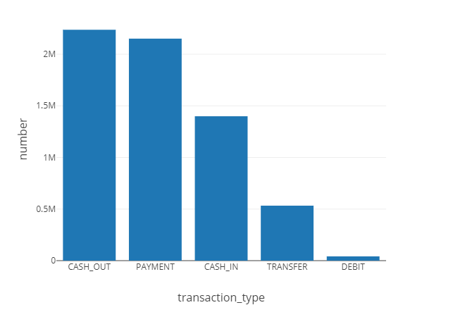

### These results show that the most common types of transactions by far are Cash outs and Payments. After that for transaction frequency come Cash Ins, Transfers, and Debits. Debits make up a tiny proportion of the overall number of transactions.

### 10. Create a new column that labels the transaction as suspicious. The new column should be called label and take the value of 1 if:

- The oldbalanceOrg is less than 54000 and the type of transaction is a transfer and the new balance is less than or equal to 105, or
- The oldbalanceOrg is greater than 56900 and he newbalanceOrig is less than or equal to 12, or
- The oldbalanceOrg is greater than 56900 and the newbalanceOrig is greater than 12 and the amount is greater than 1160000,

```python
%python
import pyspark.sql.functions as F

df1 = df1.withColumn("label", F.when(
                    (df1["oldbalanceOrg"] < 54000) & (df1["type"] == "TRANSFER") & (df1["newbalanceOrig"] <=105) |
                    (df1["oldbalanceOrg"] > 56900) & (df1["newbalanceOrig"] <= 12) |
                    (df1["oldbalanceOrg"] > 56900) & (df1["newbalanceOrig"] > 12) & (df["amount"] > 1160000),
                    1).otherwise(0))
display(df1)
```

| step | type | amount | nameOrig | oldbalanceOrg | newbalanceOrig | nameDest | oldbalanceDest | newbalanceDest | isFraud | isFlaggedFraud | destination_diff | label |
| --- | --- | --- | --- | --- | --- | --- | --- | --- | --- | --- | --- | --- |
| 1 | PAYMENT | 9839.64 | C1231006815 | 170136.0 | 160296.36 | M1979787155 | 0.0 | 0.0 | 0 | 0 | 0.0 | 0 |
| 1 | PAYMENT | 1864.28 | C1666544295 | 21249.0 | 19384.72 | M2044282225 | 0.0 | 0.0 | 0 | 0 | 0.0 | 0 |
| 1 | TRANSFER | 181.0 | C1305486145 | 181.0 | 0.0 | C553264065 | 0.0 | 0.0 | 1 | 0 | 0.0 | 1 |
| 1 | CASH_OUT | 181.0 | C840083671 | 181.0 | 0.0 | C38997010 | 21182.0 | 0.0 | 1 | 0 | -21182.0 | 0 |
| 1 | PAYMENT | 11668.14 | C2048537720 | 41554.0 | 29885.86 | M1230701703 | 0.0 | 0.0 | 0 | 0 | 0.0 | 0 |
| 1 | PAYMENT | 7817.71 | C90045638 | 53860.0 | 46042.29 | M573487274 | 0.0 | 0.0 | 0 | 0 | 0.0 | 0 |
| 1 | PAYMENT | 7107.77 | C154988899 | 183195.0 | 176087.23 | M408069119 | 0.0 | 0.0 | 0 | 0 | 0.0 | 0 |
| 1 | PAYMENT | 7861.64 | C1912850431 | 176087.23 | 168225.59 | M633326333 | 0.0 | 0.0 | 0 | 0 | 0.0 | 0 |
| 1 | PAYMENT | 4024.36 | C1265012928 | 2671.0 | 0.0 | M1176932104 | 0.0 | 0.0 | 0 | 0 | 0.0 | 0 |
| 1 | DEBIT | 5337.77 | C712410124 | 41720.0 | 36382.23 | C195600860 | 41898.0 | 40348.79 | 0 | 0 | -1549.2099999999991 | 0 |
| 1 | DEBIT | 9644.94 | C1900366749 | 4465.0 | 0.0 | C997608398 | 10845.0 | 157982.12 | 0 | 0 | 147137.12 | 0 |
| 1 | PAYMENT | 3099.97 | C249177573 | 20771.0 | 17671.03 | M2096539129 | 0.0 | 0.0 | 0 | 0 | 0.0 | 0 |
| 1 | PAYMENT | 2560.74 | C1648232591 | 5070.0 | 2509.26 | M972865270 | 0.0 | 0.0 | 0 | 0 | 0.0 | 0 |
| 1 | PAYMENT | 11633.76 | C1716932897 | 10127.0 | 0.0 | M801569151 | 0.0 | 0.0 | 0 | 0 | 0.0 | 0 |
| 1 | PAYMENT | 4098.78 | C1026483832 | 503264.0 | 499165.22 | M1635378213 | 0.0 | 0.0 | 0 | 0 | 0.0 | 0 |
| 1 | CASH_OUT | 229133.94 | C905080434 | 15325.0 | 0.0 | C476402209 | 5083.0 | 51513.44 | 0 | 0 | 46430.44 | 0 |
| 1 | PAYMENT | 1563.82 | C761750706 | 450.0 | 0.0 | M1731217984 | 0.0 | 0.0 | 0 | 0 | 0.0 | 0 |
| 1 | PAYMENT | 1157.86 | C1237762639 | 21156.0 | 19998.14 | M1877062907 | 0.0 | 0.0 | 0 | 0 | 0.0 | 0 |
| 1 | PAYMENT | 671.64 | C2033524545 | 15123.0 | 14451.36 | M473053293 | 0.0 | 0.0 | 0 | 0 | 0.0 | 0 |
| 1 | TRANSFER | 215310.3 | C1670993182 | 705.0 | 0.0 | C1100439041 | 22425.0 | 0.0 | 0 | 0 | -22425.0 | 1 |
| 1 | PAYMENT | 1373.43 | C20804602 | 13854.0 | 12480.57 | M1344519051 | 0.0 | 0.0 | 0 | 0 | 0.0 | 0 |
| 1 | DEBIT | 9302.79 | C1566511282 | 11299.0 | 1996.21 | C1973538135 | 29832.0 | 16896.7 | 0 | 0 | -12935.3 | 0 |
| 1 | DEBIT | 1065.41 | C1959239586 | 1817.0 | 751.59 | C515132998 | 10330.0 | 0.0 | 0 | 0 | -10330.0 | 0 |
| 1 | PAYMENT | 3876.41 | C504336483 | 67852.0 | 63975.59 | M1404932042 | 0.0 | 0.0 | 0 | 0 | 0.0 | 0 |
| 1 | TRANSFER | 311685.89 | C1984094095 | 10835.0 | 0.0 | C932583850 | 6267.0 | 2719172.89 | 0 | 0 | 2712905.89 | 1 |
| 1 | PAYMENT | 6061.13 | C1043358826 | 443.0 | 0.0 | M1558079303 | 0.0 | 0.0 | 0 | 0 | 0.0 | 0 |
| 1 | PAYMENT | 9478.39 | C1671590089 | 116494.0 | 107015.61 | M58488213 | 0.0 | 0.0 | 0 | 0 | 0.0 | 0 |
| 1 | PAYMENT | 8009.09 | C1053967012 | 10968.0 | 2958.91 | M295304806 | 0.0 | 0.0 | 0 | 0 | 0.0 | 0 |
| 1 | PAYMENT | 8901.99 | C1632497828 | 2958.91 | 0.0 | M33419717 | 0.0 | 0.0 | 0 | 0 | 0.0 | 0 |
| 1 | PAYMENT | 9920.52 | C764826684 | 0.0 | 0.0 | M1940055334 | 0.0 | 0.0 | 0 | 0 | 0.0 | 0 |

[output cut: 970 more lines]

Showing the first 1000 rows.

### 11. Otherwise, the value should be 0.

```python
%python
display(df1)
```

| step | type | amount | nameOrig | oldbalanceOrg | newbalanceOrig | nameDest | oldbalanceDest | newbalanceDest | isFraud | isFlaggedFraud | destination_diff | label |
| --- | --- | --- | --- | --- | --- | --- | --- | --- | --- | --- | --- | --- |
| 1 | PAYMENT | 9839.64 | C1231006815 | 170136.0 | 160296.36 | M1979787155 | 0.0 | 0.0 | 0 | 0 | 0.0 | 0 |
| 1 | PAYMENT | 1864.28 | C1666544295 | 21249.0 | 19384.72 | M2044282225 | 0.0 | 0.0 | 0 | 0 | 0.0 | 0 |
| 1 | TRANSFER | 181.0 | C1305486145 | 181.0 | 0.0 | C553264065 | 0.0 | 0.0 | 1 | 0 | 0.0 | 1 |
| 1 | CASH_OUT | 181.0 | C840083671 | 181.0 | 0.0 | C38997010 | 21182.0 | 0.0 | 1 | 0 | -21182.0 | 0 |
| 1 | PAYMENT | 11668.14 | C2048537720 | 41554.0 | 29885.86 | M1230701703 | 0.0 | 0.0 | 0 | 0 | 0.0 | 0 |
| 1 | PAYMENT | 7817.71 | C90045638 | 53860.0 | 46042.29 | M573487274 | 0.0 | 0.0 | 0 | 0 | 0.0 | 0 |
| 1 | PAYMENT | 7107.77 | C154988899 | 183195.0 | 176087.23 | M408069119 | 0.0 | 0.0 | 0 | 0 | 0.0 | 0 |
| 1 | PAYMENT | 7861.64 | C1912850431 | 176087.23 | 168225.59 | M633326333 | 0.0 | 0.0 | 0 | 0 | 0.0 | 0 |
| 1 | PAYMENT | 4024.36 | C1265012928 | 2671.0 | 0.0 | M1176932104 | 0.0 | 0.0 | 0 | 0 | 0.0 | 0 |
| 1 | DEBIT | 5337.77 | C712410124 | 41720.0 | 36382.23 | C195600860 | 41898.0 | 40348.79 | 0 | 0 | -1549.2099999999991 | 0 |
| 1 | DEBIT | 9644.94 | C1900366749 | 4465.0 | 0.0 | C997608398 | 10845.0 | 157982.12 | 0 | 0 | 147137.12 | 0 |
| 1 | PAYMENT | 3099.97 | C249177573 | 20771.0 | 17671.03 | M2096539129 | 0.0 | 0.0 | 0 | 0 | 0.0 | 0 |
| 1 | PAYMENT | 2560.74 | C1648232591 | 5070.0 | 2509.26 | M972865270 | 0.0 | 0.0 | 0 | 0 | 0.0 | 0 |
| 1 | PAYMENT | 11633.76 | C1716932897 | 10127.0 | 0.0 | M801569151 | 0.0 | 0.0 | 0 | 0 | 0.0 | 0 |
| 1 | PAYMENT | 4098.78 | C1026483832 | 503264.0 | 499165.22 | M1635378213 | 0.0 | 0.0 | 0 | 0 | 0.0 | 0 |
| 1 | CASH_OUT | 229133.94 | C905080434 | 15325.0 | 0.0 | C476402209 | 5083.0 | 51513.44 | 0 | 0 | 46430.44 | 0 |
| 1 | PAYMENT | 1563.82 | C761750706 | 450.0 | 0.0 | M1731217984 | 0.0 | 0.0 | 0 | 0 | 0.0 | 0 |
| 1 | PAYMENT | 1157.86 | C1237762639 | 21156.0 | 19998.14 | M1877062907 | 0.0 | 0.0 | 0 | 0 | 0.0 | 0 |
| 1 | PAYMENT | 671.64 | C2033524545 | 15123.0 | 14451.36 | M473053293 | 0.0 | 0.0 | 0 | 0 | 0.0 | 0 |
| 1 | TRANSFER | 215310.3 | C1670993182 | 705.0 | 0.0 | C1100439041 | 22425.0 | 0.0 | 0 | 0 | -22425.0 | 1 |
| 1 | PAYMENT | 1373.43 | C20804602 | 13854.0 | 12480.57 | M1344519051 | 0.0 | 0.0 | 0 | 0 | 0.0 | 0 |
| 1 | DEBIT | 9302.79 | C1566511282 | 11299.0 | 1996.21 | C1973538135 | 29832.0 | 16896.7 | 0 | 0 | -12935.3 | 0 |
| 1 | DEBIT | 1065.41 | C1959239586 | 1817.0 | 751.59 | C515132998 | 10330.0 | 0.0 | 0 | 0 | -10330.0 | 0 |
| 1 | PAYMENT | 3876.41 | C504336483 | 67852.0 | 63975.59 | M1404932042 | 0.0 | 0.0 | 0 | 0 | 0.0 | 0 |
| 1 | TRANSFER | 311685.89 | C1984094095 | 10835.0 | 0.0 | C932583850 | 6267.0 | 2719172.89 | 0 | 0 | 2712905.89 | 1 |
| 1 | PAYMENT | 6061.13 | C1043358826 | 443.0 | 0.0 | M1558079303 | 0.0 | 0.0 | 0 | 0 | 0.0 | 0 |
| 1 | PAYMENT | 9478.39 | C1671590089 | 116494.0 | 107015.61 | M58488213 | 0.0 | 0.0 | 0 | 0 | 0.0 | 0 |
| 1 | PAYMENT | 8009.09 | C1053967012 | 10968.0 | 2958.91 | M295304806 | 0.0 | 0.0 | 0 | 0 | 0.0 | 0 |
| 1 | PAYMENT | 8901.99 | C1632497828 | 2958.91 | 0.0 | M33419717 | 0.0 | 0.0 | 0 | 0 | 0.0 | 0 |
| 1 | PAYMENT | 9920.52 | C764826684 | 0.0 | 0.0 | M1940055334 | 0.0 | 0.0 | 0 | 0 | 0.0 | 0 |

[output cut: 970 more lines]

Showing the first 1000 rows.

### 12. Calculate the percentage of transactions labeled suspicious (“label”) out of all transactions

```python
%python
sus = df1.filter(df1["label"] == 1).count()
total = df1.count()
perc = (sus / total) * 100
str(round(perc, 2))
```

Out[14]: '10.92'

### 13. Import StringIndexer, OneHotEncoder, and VectorAssembler from pyspark. Explain what each of these PySpark processing tools is used for.

```python
%python
## ML Pre-processing
from pyspark.ml.feature import StringIndexer
from pyspark.ml.feature import OneHotEncoder
from pyspark.ml.feature import VectorAssembler
```

### StringIndexer is used to convert categorical features/variables to numeric vectors. Aso converts binary categorical columns to binary vectors as labels or features. OneHotEncoder maps label indices to a binary representation using a sparse vector. VectorAssembler combines all features columns into a single feature vector that's required by Spark MLlib

### 14. Convert the column “type” to a numeric column of indices called typeIdx

```python
%python
df1 = StringIndexer(inputCol = "type", outputCol = "typeldx").fit(df1).transform(df1)

%python
df1.show()
```

[output not shown]

### 15. Encode “typeIdx” to create a binary representation of it called “type_bins”

```python
%python
df1 = OneHotEncoder(inputCol = "typeldx", outputCol = "type_bins").fit(df1).transform(df1)


%python
display(df1)
```

[output not shown]

### 16. The “type_bins” feature is stored as a SparseVector. What is a SparseVector and why does Spark use it to store data?

- Assemble the columns into a single vector column with the following input columns: "type_bins","amount","oldbalanceOrg", "newbalanceOrig", "oldbalanceDest", "newbalanceDest", "destination_diff". Call the output column “features” and select “features” and “label.”

### A sparse vector hides the zeroes in a vector. Spark does this in order to conserve space.A sparse vector specifies the size of the vector, the vector positions that are non-zero, and the values of those non-zero positions.

```python
%python
modeling_df = VectorAssembler(inputCols = ["type_bins",
                                           "amount",
                                           "oldbalanceOrg",
                                           "newbalanceOrig",
                                           "oldbalanceDest",
                                           "newbalanceDest",
                                           "destination_diff"],
                             outputCol = "features").transform(df1).select("features", "label")
modeling_df.show()
```

+--------------------+-----+ features|label| +--------------------+-----+ (10,[1,4,5,6],[1....| 0| (10,[1,4,5,6],[1....| 0| (10,[3,4,5],[1.0,...| 1| (10,[0,4,5,7,9],[...| 0| (10,[1,4,5,6],[1....| 0| (10,[1,4,5,6],[1....| 0| (10,[1,4,5,6],[1....| 0| (10,[1,4,5,6],[1....| 0| (10,[1,4,5],[1.0,...| 0| [0.0,0.0,0.0,0.0,...| 0| (10,[4,5,7,8,9],[...| 0| (10,[1,4,5,6],[1....| 0| (10,[1,4,5,6],[1....| 0| (10,[1,4,5],[1.0,...| 0| (10,[1,4,5,6],[1....| 0| [1.0,0.0,0.0,0.0,...| 0| (10,[1,4,5],[1.0,...| 0| (10,[1,4,5,6],[1....| 0| (10,[1,4,5,6],[1....| 0| (10,[3,4,5,7,9],[...| 1| +--------------------+-----+ only showing top 20 rows

### 17. Split the data into train and test sets with 30% held out for testing.

```python
%python
from pyspark.ml.classification import LogisticRegression
df_train, df_test = modeling_df.randomSplit([0.7, 0.3])
```

### 18. Import the DecisionTreeClassifier from pyspark.

```python
%python
from pyspark.ml.classification import DecisionTreeClassifier
```

### 19. Instantiate the model

```python
%python
dec_tree = DecisionTreeClassifier(labelCol = "label", featuresCol = "features", seed = 123, maxDepth = 3)
```

### 20. Fit the model to training data

```python
%python
fitted_mod = dec_tree.fit(df_train)
```

```python
%python
display(fitted_mod)
```

| treeNode |
| --- |
| {"index":5,"featureType":"categorical","prediction":null,"threshold":null,"categories":[0.0],"feature":3,"overflow":false} |
| {"index":1,"featureType":"continuous","prediction":null,"threshold":111086.31999999989,"categories":null,"feature":9,"overflow":false} |
| {"index":0,"featureType":null,"prediction":0.0,"threshold":null,"categories":null,"feature":null,"overflow":false} |
| {"index":3,"featureType":"continuous","prediction":null,"threshold":59901.5,"categories":null,"feature":5,"overflow":false} |
| {"index":2,"featureType":null,"prediction":0.0,"threshold":null,"categories":null,"feature":null,"overflow":false} |
| {"index":4,"featureType":null,"prediction":1.0,"threshold":null,"categories":null,"feature":null,"overflow":false} |
| {"index":7,"featureType":"continuous","prediction":null,"threshold":93.6,"categories":null,"feature":6,"overflow":false} |
| {"index":6,"featureType":null,"prediction":1.0,"threshold":null,"categories":null,"feature":null,"overflow":false} |
| {"index":9,"featureType":"continuous","prediction":null,"threshold":805325.0700000001,"categories":null,"feature":4,"overflow":false} |
| {"index":8,"featureType":null,"prediction":0.0,"threshold":null,"categories":null,"feature":null,"overflow":false} |
| {"index":10,"featureType":null,"prediction":1.0,"threshold":null,"categories":null,"feature":null,"overflow":false} |

[figure not shown]

### 21. Make predictions using the test data

```python
%python
predicts = fitted_mod.transform(df_test)
```

### 22. Evaluate the model using the BinaryClassificationEvaluator by using the predictions to get the Area under the ROC and save this number as a variable called dt_auc.

```python
%python
from pyspark.ml.evaluation import BinaryClassificationEvaluator

#instantiate evaluator object
evaluator = BinaryClassificationEvaluator(labelCol = "label",
                                         rawPredictionCol = "prediction",
                                         metricName = "areaUnderROC")
dt_auc = evaluator.evaluate(predicts)
print(f"Area under ROC: {dt_auc}")
```

Area under ROC: 0.973111720340154

### 23. Perform steps 18 through 22 again but use a Random Forest Classifier instead of a Decision Tree. Save the result from the Area under the ROC step as a variable called rf_auc

```python
%python
from pyspark.ml.classification import RandomForestClassifier

%python
rand_forest = RandomForestClassifier(labelCol = "label", featuresCol = "features", seed = 123, maxDepth = 3)

%python
fitted_mod = rand_forest.fit(df_train)

%python
predicts = fitted_mod.transform(df_test)

%python
#instantiate evaluator object
evaluator = BinaryClassificationEvaluator(labelCol = "label",
                                         rawPredictionCol = "prediction",
                                         metricName = "areaUnderROC")
rf_auc = evaluator.evaluate(predicts)
print(f"Area under ROC: {rf_auc}")
```

[output not shown]

### 24. Perform steps 18 through 22 again but use a Gradient Boosted Tree instead of a Decision Tree. Save the result from the Area under the ROC step as a variable called gb_auc

```python
%python
from pyspark.ml.classification import GBTClassifier

%python
gbt = GBTClassifier(labelCol = "label", featuresCol = "features", seed = 123, maxDepth = 3)

%python
fitted_mod = gbt.fit(df_train)

%python
predicts = fitted_mod.transform(df_test)

%python
#instantiate evaluator object
evaluator = BinaryClassificationEvaluator(labelCol = "label",
                                         rawPredictionCol = "prediction",
                                         metricName = "areaUnderROC")
gb_auc = evaluator.evaluate(predicts)
print(f"Area under ROC: {gb_auc}")
```

[output not shown]

```python
%python
print(f"Area under Decision Tree ROC: {dt_auc}")
print(f"Area under Random Forest ROC: {rf_auc}")
print(f"Area under Gradient Boosted Tree ROC: {gb_auc}")
```

Area under Decision Tree ROC: 0.973111720340154 Area under Random Forest ROC: 0.8661262710518699 Area under Gradient Boosted Tree ROC: 0.9939044545536309